# sentiment analysis

chijioke obiakor

2025-02-19

# Load necessary libraries

```r
libraries <- c("tm", "tidytext", "ggplot2", "wordcloud", "syuzhet", "dplyr", "tibble", "textstem", "textdata", "tidyr", "Matrix", "topicmodels", "stringr", "reshape2", "LDAvis", "jsonlite","spacyr","NLP","proxy","igraph","textTinyR")

#install.packages(libraries) # Comment out after first execution

for (lib in libraries) {
  library(lib, character.only=TRUE) #Library takes function names without quotes, character only must be used in a loop of this kind.
}
```

# Load and inspect the dataset

```r
filepath <- "C:\\Users\\Dell\\Downloads\\MS4S09_CW_Book_Reviews.csv" # Define file path. Windows requires \ to be replaced by \\. / Works on Mac (apparently).
review_df<- as_tibble(read.csv(filepath, stringsAsFactors = FALSE)) # Since we have text data we do not want this read as a factor

# Inspect summary and first few rows of data
print(summary(review_df))
```

```
##     Title             Book_Price     Reviewer_id            Rating
##  Length:59296       Min.   :  1.00   Length:59296       Min.   :1.000
##  Class :character   1st Qu.: 10.36   Class :character   1st Qu.:4.000
##  Mode  :character   Median : 14.15   Mode  :character   Median :5.000
##                     Mean   : 20.81                      Mean   :4.231
##                     3rd Qu.: 22.99                      3rd Qu.:5.000
##                     Max.   :995.00                      Max.   :5.000
##       Time           Review_title       Review_text        Found_helpful_ratio
##  Min.   :8.688e+08   Length:59296       Length:59296       Min.   :0.0000
##  1st Qu.:1.087e+09   Class :character   Class :character   1st Qu.:0.0000
##  Median :1.169e+09   Mode  :character   Mode  :character   Median :0.6667
##  Mean   :1.173e+09                                         Mean   :0.5491
##  3rd Qu.:1.279e+09                                         3rd Qu.:1.0000
##  Max.   :1.362e+09                                         Max.   :1.0000
##   Publisher         First_author          Genre
##  Length:59296       Length:59296       Length:59296
##  Class :character   Class :character   Class :character
##  Mode  :character   Mode  :character   Mode  :character
##
##
##
```

```r
print(head(review_df))
```

```
## # A tibble: 6 × 11
##   Title            Book_Price Reviewer_id Rating   Time Review_title Review_text
##   <chr>                 <dbl> <chr>        <int>  <int> <chr>        <chr>
## 1 In Six Days: Wh…      10.2  APD7XINUVG…      4 9.99e8 Solid testi… "Working f…
## 2 Lord Jim              15.6  AITANZIKX8…      5 9.16e8 &quot;You d… "A terrifi…
## 3 White Socks Only       5.16 AYB19RB36G…      4 1.34e9 White Socks… "As I open…
## 4 The Secret of t…      15.0  A1BOLCK0Q5…      5 1.28e9 great!       "Excellent…
## 5 Left to Tell: D…      17.5  A3WKJ88K78…      5 1.36e9 Great Book   "This book…
## 6 Don't Make Me T…      20.9  A1E6I4IPWW…      5 1.20e9 Don't think… "Excellent…
## # ℹ 4 more variables: Found_helpful_ratio <dbl>, Publisher <chr>,
## #   First_author <chr>, Genre <chr>
```

# Data selection and sampling

```r
review_df<- review_df[,c(1,3,4,6,7)] # Select  needed columns

review_df<- na.omit(review_df) # Removes all rows containing null values
```

```r
unique_values <- unique(review_df$Title)
num_unique_values <- length(unique_values)

# Print the number of unique values
print(num_unique_values)
```

```
## [1] 17939
```

```r
book_reviews_count <- table(review_df$Title)



# Step 2: Filter restaurants with over 20 reviews
book_over_50_reviews<- names(book_reviews_count)[book_reviews_count > 50]
print(book_over_50_reviews)
```

```
##  [1] "1491: New Revelations of the Americas Before Columbus"
##  [2] "23 Minutes In Hell: One Man's Story About What He Saw, Heard, and Felt in that Place of Torment"
##  [3] "A Breath of Snow and Ashes (Outlander)"
##  [4] "A Hunger Like No Other (Immortals After Dark, Book 1)"
##  [5] "A Lesson Before Dying (Library Edition Audio CDs) (Audio Theatre Collection)"
##  [6] "A People's History of the United States: 1492 to Present"
##  [7] "Alice's Adventures in Wonderland (Aladdin Classics)"
##  [8] "America Alone: The End of the World as We Know It"
##  [9] "Be Prepared: A Practical Handbook for New Dads"
## [10] "Blue Like Jazz: Nonreligious Thoughts on Christian Spirituality"
## [11] "Bringing Down the House: The Inside Story of Six M.I.T. Students Who Took Vegas for Millions"
## [12] "Don't Make Me Think: A Common Sense Approach to Web Usability, 2nd Edition"
## [13] "Eating For Life"
## [14] "Elantris"
## [15] "Eldest (Inheritance, Book 2)"
```

[output cut: 49 more lines]

```r
review_df<- review_df%>%filter(Title %in% book_over_50_reviews)
```

```r
set.seed(124)
sample_index<- sample(length(unique(review_df$Title)), 10)
sampled_title<- unique(review_df$Title)[sample_index]

review_df <- review_df%>%filter(Title %in% sampled_title)

print(summary(review_df))
```

```
##     Title           Reviewer_id            Rating      Review_title
##  Length:1153        Length:1153        Min.   :1.000   Length:1153
##  Class :character   Class :character   1st Qu.:4.000   Class :character
##  Mode  :character   Mode  :character   Median :5.000   Mode  :character
##                                        Mean   :4.338
##                                        3rd Qu.:5.000
##                                        Max.   :5.000
##  Review_text
##  Length:1153
##  Class :character
##  Mode  :character
##
##
##
```

```r
head(review_df)
```

```
## # A tibble: 6 × 5
##   Title                              Reviewer_id Rating Review_title Review_text
##   <chr>                              <chr>        <int> <chr>        <chr>
## 1 Left to Tell: Discovering God Ami… A3WKJ88K78…      5 Great Book   "This book…
## 2 Tear Soup: A Recipe for Healing A… A140K1TY6H…      5 My Favorite… "Written i…
## 3 Good to Great                      A1YE0A10QR…      5 Good to Gre… "An excell…
## 4 A Breath of Snow and Ashes (Outla… A3KOIC6FPJ…      5 Actually 4 … "I have so…
## 5 Left to Tell: Discovering God Ami… A2NB4JARP2…      5 Inspiration… "Left to T…
## 6 I Feel Bad About My Neck: And Oth… A2VJ4VB339…      4 I Feel Bad … "A very ea…
```

# Tokenization(word)

```r
word_tokenized_data <- review_df %>%
  unnest_tokens(output = word, input = Review_text, token = "words", to_lower = TRUE)
```

# plot of top 12 words

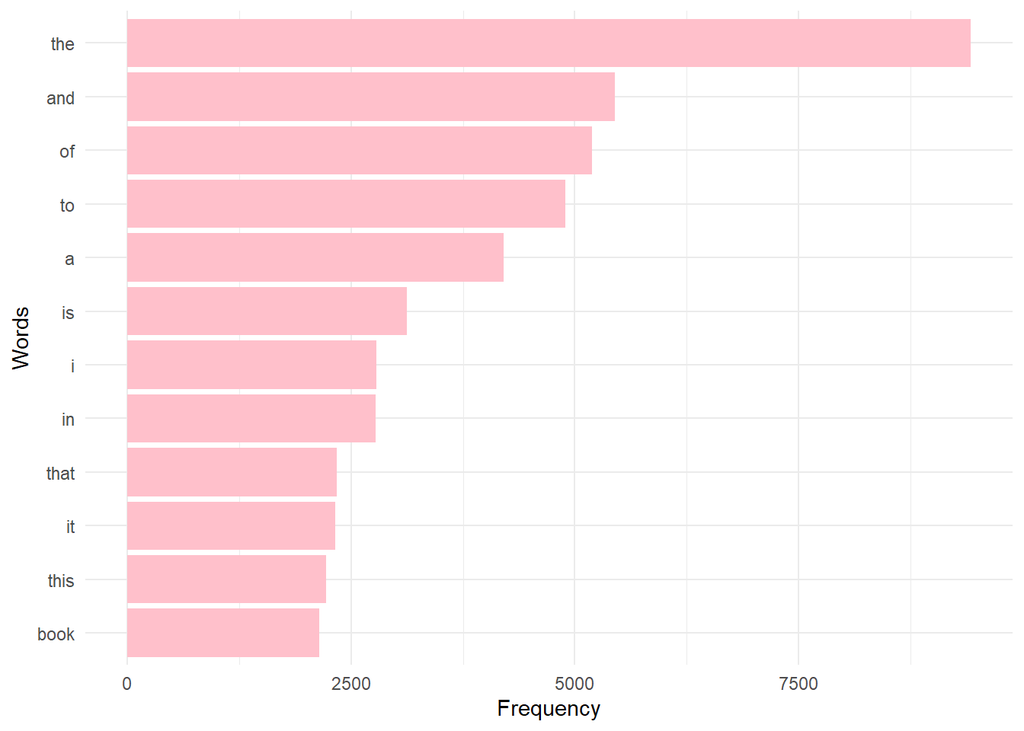

```r
word_count<- word_tokenized_data%>% count(word,sort = TRUE)

ggplot(word_count[1:12, ], aes(x = reorder(word, n), y = n)) + # Plots first 10 rows of word counts, with word (ordered by n) on the x axis and n on the y axis
  geom_col(fill = "pink") + # Sets colours of bars to blue
  labs(x = "Words", y = "Frequency") + # Defines x and y labels
  coord_flip() + # Flips coordinates so words go on the y axis (for readability)
  theme_minimal() # Sets theme of visualisation
```

# word cloud

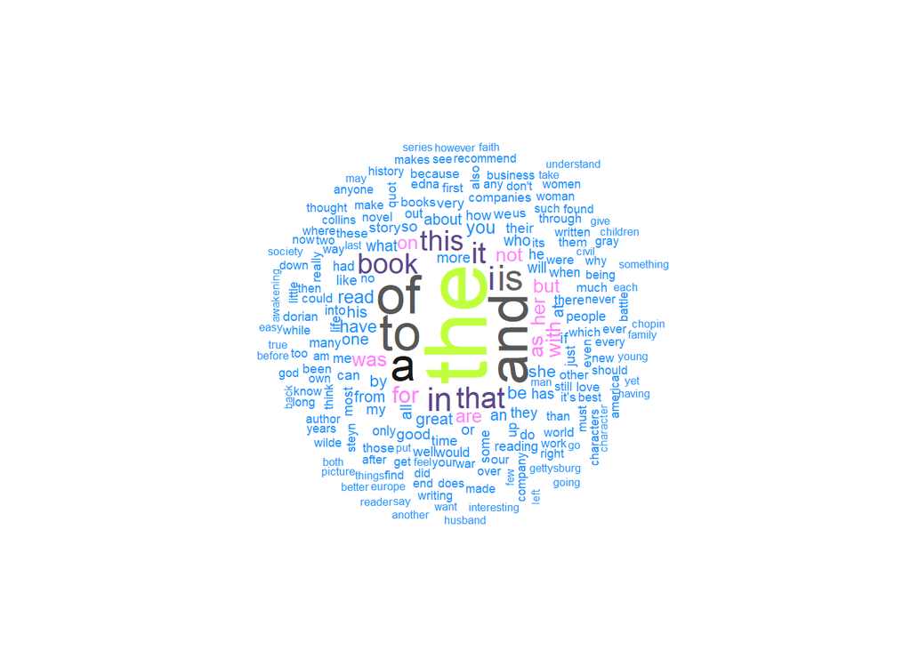

```r
set.seed(1)
wordcloud(words=word_count$word, freq = word_count$n, min.freq = 100, random.order = FALSE, random.color =FALSE, colors = sample(colors(), size = 10))
```

# cleaning the data

```r
clean_tokens <- word_tokenized_data %>%
  anti_join(stop_words, by = "word") # Removes stop words

clean_tokens$word <- gsub("[^a-zA-Z ]", "", clean_tokens$word) %>% # Remove special characters and numbers
  na_if("") %>% # Replaces empty strings with NA
  lemmatize_words() # Lemmatizes text

clean_tokens <- na.omit(clean_tokens) # Removes null values
```

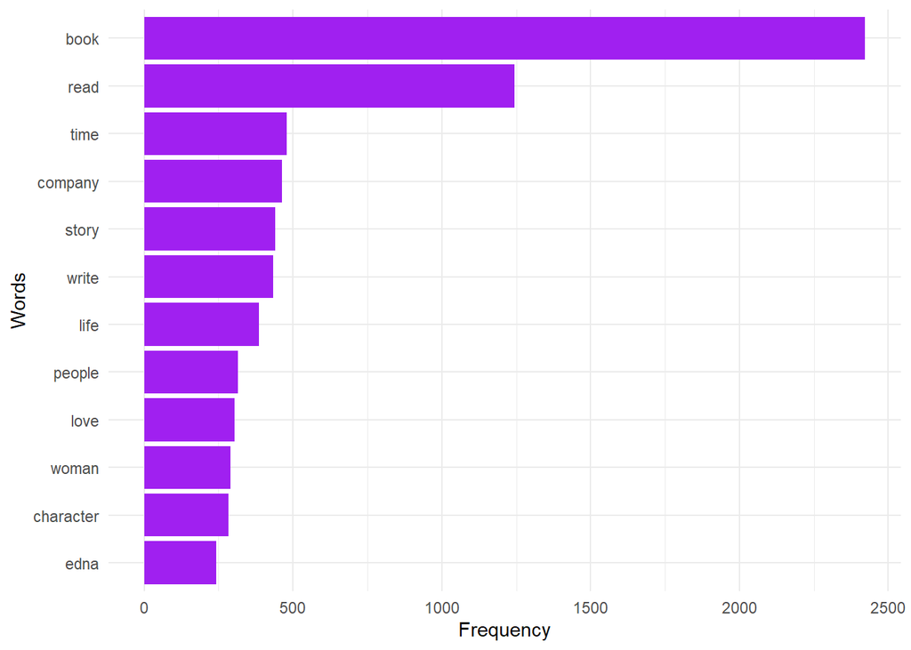

```r
word_count<- clean_tokens%>% count(word,sort = TRUE)

ggplot(word_count[1:12, ], aes(x = reorder(word, n), y = n)) + # Plots first 10 rows of word counts, with word (ordered by n) on the x axis and n on the y axis
  geom_col(fill = "purple") + # Sets colours of bars to blue
  labs(x = "Words", y = "Frequency") + # Defines x and y labels
  coord_flip() + # Flips coordinates so words go on the y axis (for readability)
  theme_minimal() # Sets theme of visualisation
```

# tokeniztion and plots (bigram)

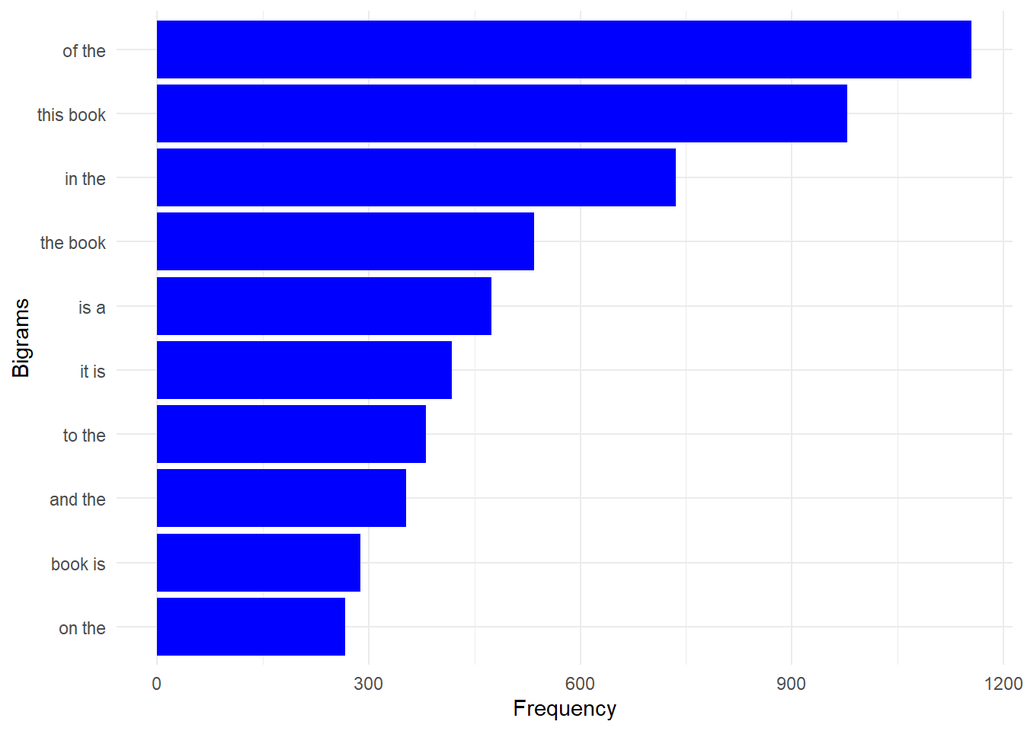

```r
bigram_tokenized_data <- review_df %>%
  unnest_tokens(output = bigram, input = Review_text, token = "ngrams", n=2, to_lower = TRUE)

bigram_counts <- bigram_tokenized_data %>%
  count(bigram, sort = TRUE)

ggplot(bigram_counts[1:10, ], aes(x = reorder(bigram, n), y = n)) +
  geom_col(fill = "blue") +
  labs(x = "Bigrams", y = "Frequency") +
  coord_flip() +
  theme_minimal()
```

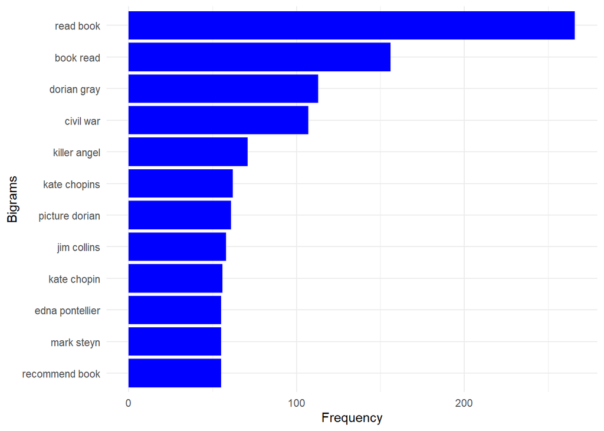

```r
untokenized_data <- clean_tokens %>%
  group_by(Reviewer_id) %>%
  summarize(clean_review = paste(word, collapse = " ")) %>%
  inner_join(review_df, by="Reviewer_id")

clean_bigrams <- untokenized_data %>%
  unnest_tokens(output = bigram, input = clean_review, token = "ngrams", n=2, to_lower = TRUE) # Tokenize word column to bigrams

bigram_counts <- clean_bigrams %>%
  count(bigram, sort = TRUE)

top_bigrams <- top_n(bigram_counts,10,n)$bigram

filtered_bigram_counts <- filter(bigram_counts, bigram %in% top_bigrams)
filtered_bigram_counts$bigram <- factor(filtered_bigram_counts$bigram, levels = top_bigrams[length(top_bigrams):1])

ggplot(filtered_bigram_counts, aes(x = reorder(bigram, n), y = n)) +
  geom_col(fill = "blue") +
  labs(x = "Bigrams", y = "Frequency") +
  coord_flip() +
  theme_minimal()
```

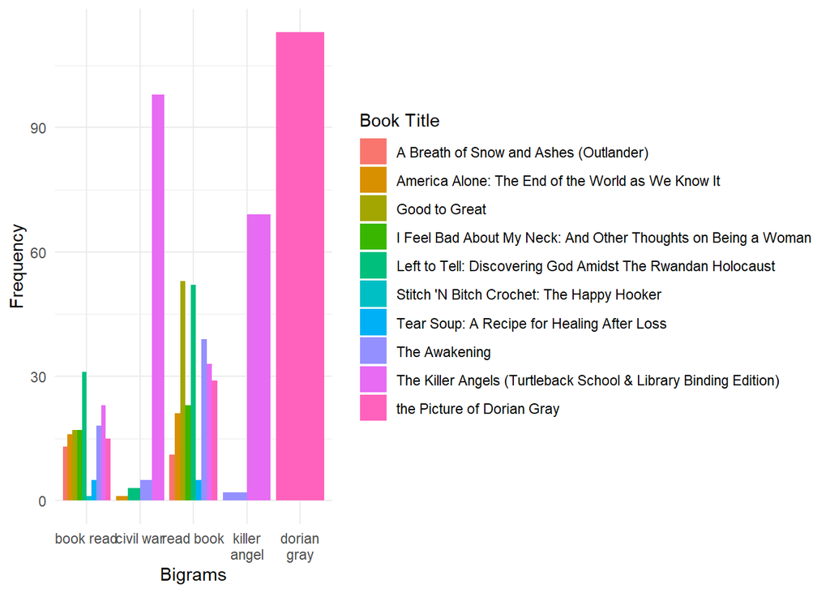

```r
top_bigrams <- top_n(bigram_counts,5,n)$bigram

grouped_count <- group_by(clean_bigrams, Title) %>%
  count(bigram) %>%
  filter(bigram %in% top_bigrams)

grouped_count$bigram <- factor(grouped_count$bigram, levels = top_bigrams[length(top_bigrams):1])



# Rotate x-axis labels
ggplot(data = grouped_count, aes(x = reorder(bigram, n), y = n, fill = Title)) +
  geom_col(position = "dodge") +
  labs(x = "Bigrams", y = "Frequency", fill = "Book Title") +
  scale_x_discrete(labels = function(x) str_wrap(x, width = 10)) +  # Wrap text
  theme(axis.text.x = element_text(angle = 45, hjust = 1)) +  # Rotate labels
  theme_minimal()
```

## SUMMARY

7. Word Tokenization: Tokenizes the review text into individual words.
8. Word Count Visualization: Calculates word frequencies and visualizes the top words using a bar plot.
9. Word Cloud: Generates a word cloud visualization based on word frequencies.
10. Data Cleaning: Removes stop words and special characters from the tokenized words, and lemmatizes the text.
11. Clean Word Count Visualization: Calculates word frequencies after data cleaning and visualizes the top words using a bar plot.
12. Bigram Tokenization: Tokenizes the review text into bigrams (pairs of consecutive words).
13. Bigram Frequency Visualization: Calculates bigram frequencies and visualizes the top bigrams using a bar plot.
14. Cleaning the Bigram: Cleans the bigrams data, filters out top bigrams, and visualizes their frequencies using a bar plot.

Overall, this code performs exploratory text analysis on book review data, including data preprocessing, tokenization, and visualization of word and bigram frequencies.

# question 2

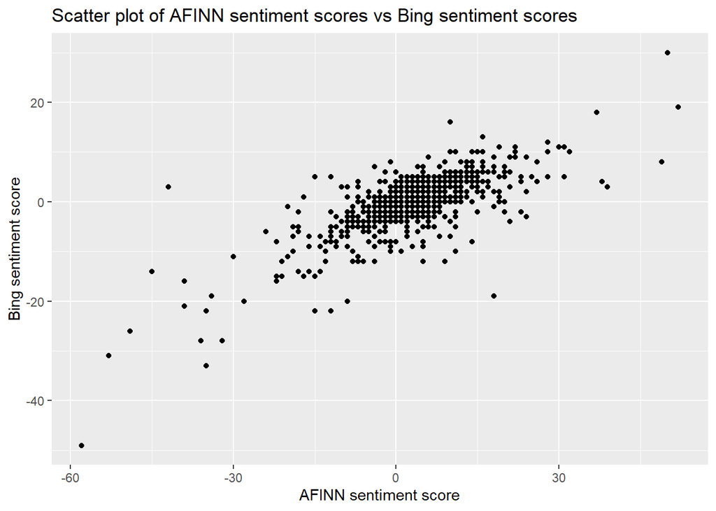

```r
# Perform sentiment analysis for bing and afinn
sentiment_data_bing <- clean_tokens %>%
  inner_join(get_sentiments("bing"), by = "word") %>%
  group_by(Reviewer_id) %>%
  summarise(bing_sentiment = sum(sentiment == "positive") - sum(sentiment == "negative"))

sentiment_data_afinn <- clean_tokens %>%
  inner_join(get_sentiments("afinn"), by = "word") %>%
  group_by(Reviewer_id) %>%
  summarise(afinn_sentiment = sum(value))

# Join sentiment scores with review_df
review_df_with_sents <- review_df %>%
  inner_join(sentiment_data_bing, by = "Reviewer_id") %>%
  inner_join(sentiment_data_afinn, by = "Reviewer_id")

# Plot scatter plot
ggplot(review_df_with_sents, aes(x = afinn_sentiment, y = bing_sentiment)) +
  geom_point() +
  labs(title = "Scatter plot of AFINN sentiment scores vs Bing sentiment scores",
       x = "AFINN sentiment score",
       y = "Bing sentiment score")
```

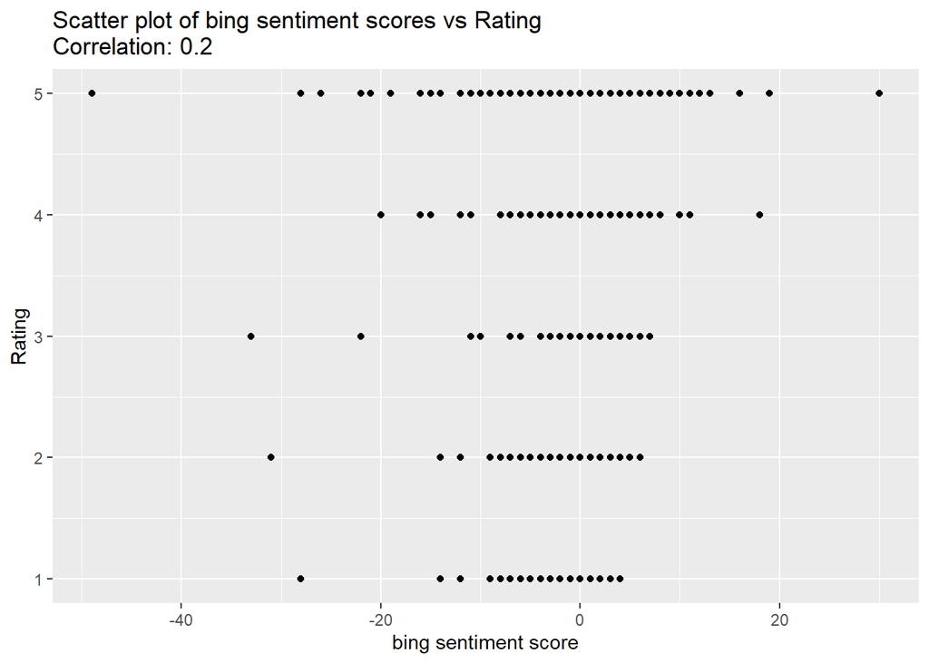

```r
correlation <- cor(review_df_with_sents$bing_sentiment, review_df_with_sents$Rating)
ggplot(review_df_with_sents, aes(x = bing_sentiment, y = Rating)) +
  geom_point() +
  labs(title = paste("Scatter plot of bing sentiment scores vs Rating\nCorrelation:", round(correlation, 2)),
       x = "bing sentiment score",
       y = "Rating")
```

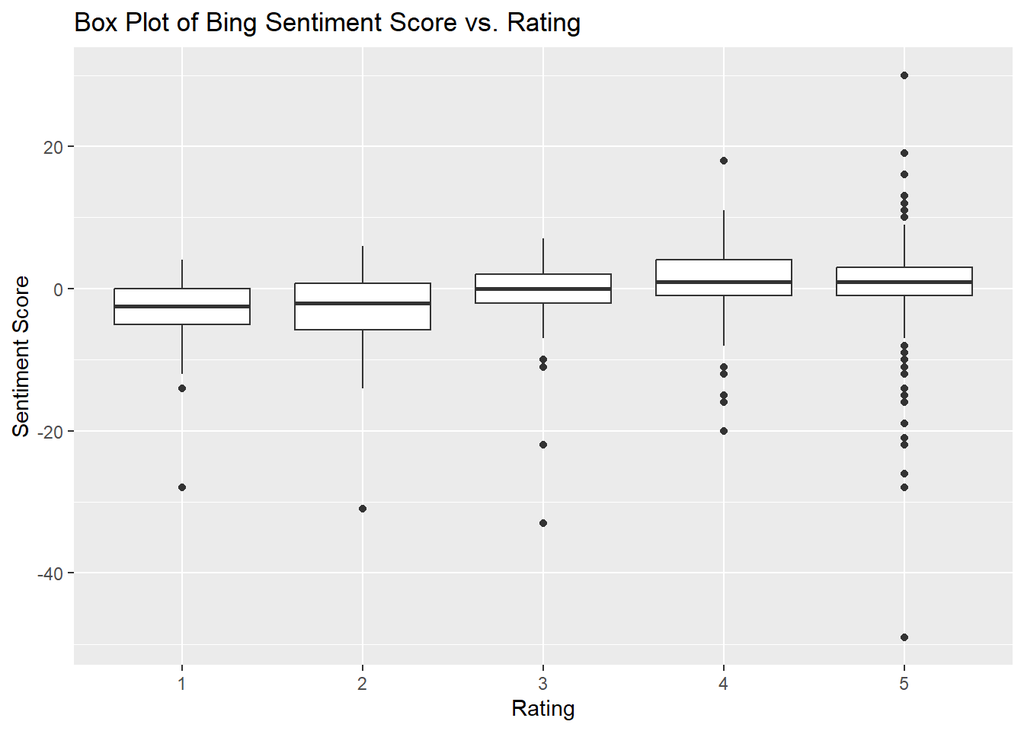

```r
review_df_with_sents$Rating <- factor(review_df_with_sents$Rating) # Convert Rating to factor

ggplot(review_df_with_sents, aes(x = Rating, y = bing_sentiment)) +
  geom_boxplot() +
  labs(title = "Box Plot of Bing Sentiment Score vs. Rating",
       x = "Rating",
       y = "Sentiment Score")
```

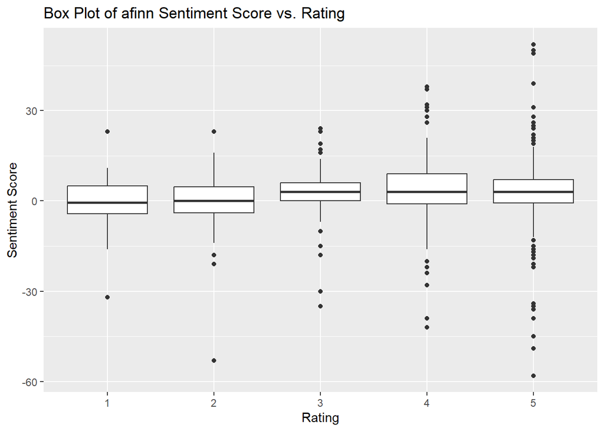

```r
ggplot(review_df_with_sents, aes(x = Rating, y = afinn_sentiment)) +
  geom_boxplot() +
  labs(title = "Box Plot of afinn Sentiment Score vs. Rating",
       x = "Rating",
       y = "Sentiment Score")
```

```r
worst_review_bing = review_df_with_sents[order(review_df_with_sents$bing_sentiment)[1], "Review_text"]

cat("Worst Review (Bing):\n", worst_review_bing$Review_text, "\n")
```

```
## Worst Review (Bing):
##  One of the more fascinating attempts at explaining the decline of the West is Mark Steyn's "America Alone." Though the main thrust of the book is the threat of Islam, Steyn examines numerous sources of decay in Western society, the upshot being that we are vulnerable to the threat only because o…
```

```r
best_review_bing = review_df_with_sents[order(review_df_with_sents$bing_sentiment, decreasing = TRUE)[1], "Review_text"]


cat("Best Review (Bing):\n", best_review_bing$Review_text, "\n\n")
```

```
## Best Review (Bing):
##  At a time when a woman's roles in society were the doting wife and devoted mother, Edna Pontellier becomes more and more aware of her distaste for these responsibilities. Kate Chopin's heroine embodies the theme of escapism and the view of marriage and motherhood as traps. During the summer at G…
```

```r
worst_review_afinn = review_df_with_sents[order(review_df_with_sents$afinn_sentiment)[1], "Review_text"]

cat("Worst Review (AFINN):\n", worst_review_afinn$Review_text, "\n")
```

```
## Worst Review (AFINN):
##  One of the more fascinating attempts at explaining the decline of the West is Mark Steyn's "America Alone." Though the main thrust of the book is the threat of Islam, Steyn examines numerous sources of decay in Western society, the upshot being that we are vulnerable to the threat only because o…
```

```r
best_review_afinn = review_df_with_sents[order(review_df_with_sents$afinn_sentiment, decreasing = TRUE)[1], "Review_text"]


cat("Best Review (AFINN):\n", best_review_afinn$Review_text, "\n\n")
```

```
## Best Review (AFINN):
##  The primary thrust of the book is to present an analysis of winning US companies and how they achieved that status. Do they have anything in common? Can we learn something from their success? Most of the conclusions and comments are simple and convincing. The author helps us to focus on the goal…
```

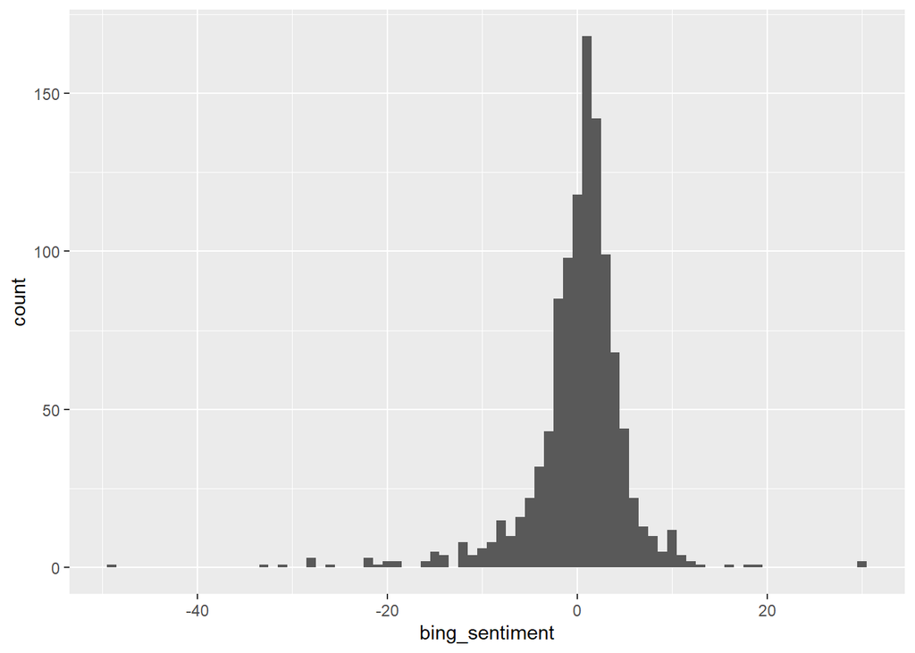

```r
ggplot(review_df_with_sents, aes(x=bing_sentiment))+
geom_histogram(binwidth=1)
```

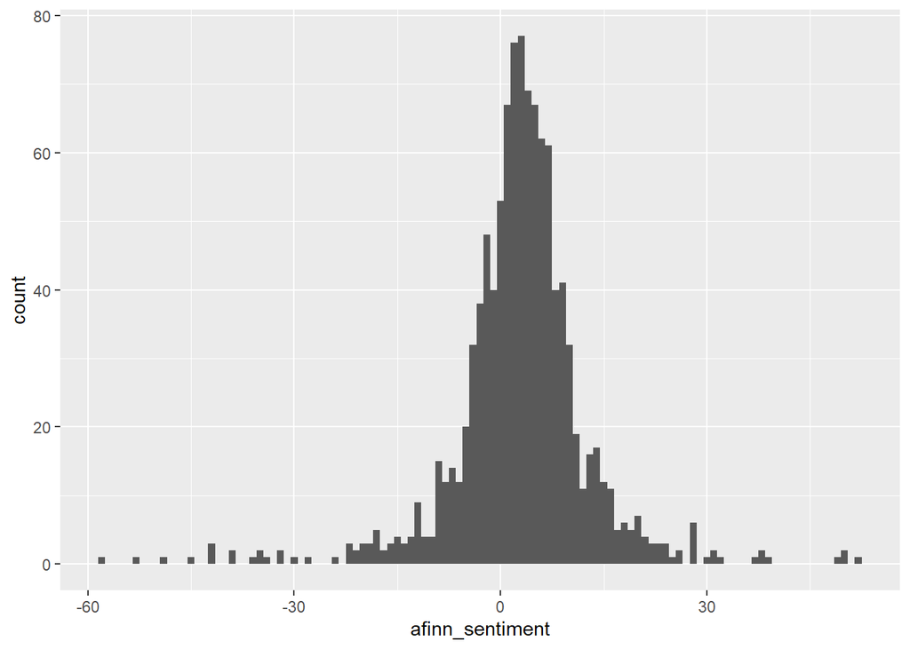

```r
ggplot(review_df_with_sents, aes(x=afinn_sentiment))+
geom_histogram(binwidth=1)
```

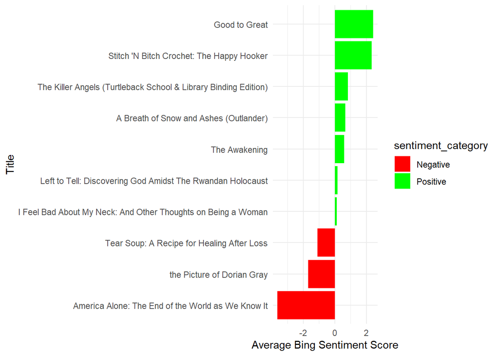

```r
book_sentiment <- review_df_with_sents %>%
  group_by(Title) %>%
  summarise(average_bing_sentiment = mean(bing_sentiment))

# Add a column indicating sentiment category (positive, negative, or neutral)
book_sentiment <- book_sentiment %>%
  mutate(sentiment_category = ifelse(average_bing_sentiment > 0, "Positive",
                                     ifelse(average_bing_sentiment < 0, "Negative", "Neutral")))

# Plot the average sentiment score by title, color-coded by sentiment category
ggplot(book_sentiment, aes(x = reorder(Title, average_bing_sentiment), y = average_bing_sentiment, fill = sentiment_category)) +
  geom_col(position = "dodge") +
  coord_flip() +
  scale_fill_manual(values = c("Positive" = "green", "Negative" = "red", "Neutral" = "grey")) +  # Specify custom colors for each sentiment category
  labs(x = "Title", y = "Average Bing Sentiment Score") +
  theme_minimal()
```

```r
emotion_data <- clean_tokens %>%
  inner_join(get_sentiments("nrc"), by = "word")
```

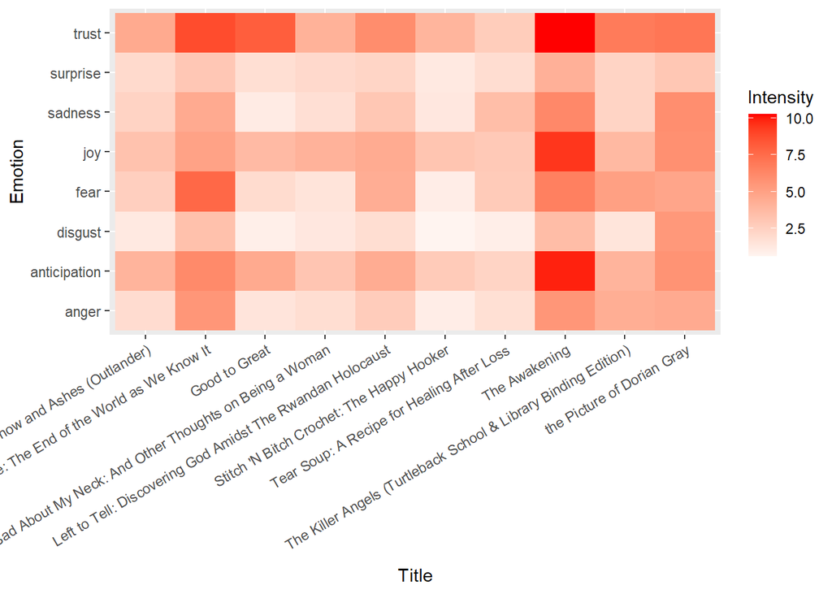

```r
# Calculate Sentiment scores for each review
emotion_count <- emotion_data %>%
  group_by(Reviewer_id) %>%
  count(sentiment)

# Pivots data so that there is a column associated with each emotion
wide_emotion_data <- emotion_count %>%
  pivot_wider(names_from = sentiment, values_from = n, values_fill = list(n = 0))

# Merge with df
review_df_with_sents <- review_df_with_sents %>%
  inner_join(wide_emotion_data, by = "Reviewer_id")

# Long format for ggplot
long_df <- review_df_with_sents %>%
  pivot_longer(cols = c("anger", "anticipation", "disgust", "fear", "joy", "sadness", "surprise", "trust"),
               names_to = "Emotion",
               values_to = "Intensity")

# Calculate average intensity of each emotion by restaurant
emotion_scores <- long_df %>%
  group_by(Title, Emotion) %>%
  summarize(avg_intensity = mean(Intensity))
# Plot
ggplot(emotion_scores, aes(x = Title, y = Emotion, fill = avg_intensity)) +
  geom_tile() +
  scale_fill_gradient2(low = "blue", high = "red") +
  labs(x = "Title", y = "Emotion", fill = "Intensity") +
  theme(axis.text.x = element_text(angle = 30, hjust=1))
```

## conclusion for sentiment analysis

Based on the observations from the scatter plot between Bing and AFINN sentiment scores, as well as the correlation analysis between sentiment scores and ratings, along with the observation regarding the choice of words leading to opposite sentiment scores, the following conclusions can be drawn:

1. –Strong Positive Correlation between Bing and AFINN Sentiment Scores:

The scatter plot between Bing and AFINN sentiment scores indicates a strong positive correlation. This suggests that the two sentiment lexicons tend to assign similar sentiment scores to the same reviews. It implies that the sentiment analysis results obtained from these lexicons are consistent with each other.

2)–Weak Positive Correlation between Sentiment Scores and Ratings:

The scatter plot between sentiment scores and ratings shows a weak positive correlation. This indicates that there is a tendency for reviews with higher sentiment scores (either from Bing or AFINN) to have slightly higher ratings. However, the correlation is not very strong, suggesting that sentiment scores alone may not be the sole determinant of ratings.

3)–Observation of Misclassification due to Choice of Words:

Upon inspecting the DataFrame, it can be observed that some positive reviews were awarded negative sentiment scores, possibly due to the choice of words. This observation suggests that sentiment analysis algorithms may misclassify the sentiment of reviews when certain words are used, leading to discrepancies between the actual sentiment expressed in the review and the sentiment score assigned by the lexicons.

4)–Implications for Sentiment Analysis and Review Interpretation:

The observed misclassification highlights the limitations of sentiment analysis algorithms, particularly when relying solely on the presence of specific words to determine sentiment. It underscores the importance of context and semantics in accurately interpreting the sentiment of text data. When interpreting reviews and sentiment analysis results, it’s crucial to consider the nuances of language and the potential impact of word choice on sentiment classification. This suggests the need for more sophisticated sentiment analysis approaches that take into account context, semantics, and linguistic nuances to improve accuracy. Overall, while Bing and AFINN sentiment scores show strong agreement and a weak positive correlation with ratings, the observation of misclassification underscores the need for caution when interpreting sentiment analysis results and emphasizes the importance of context and linguistic nuances in accurately capturing sentiment from text data